# **Lab 4**

```python
%matplotlib inline
import numpy as np
import matplotlib
import matplotlib.pyplot as plt
import scipy
import statistics
import math
from scipy import stats
import h5py
import pandas as pd
```

### **Problem 1**

We are looking at data from a gamma-ray satellite orbiting in low Earth orbit. It takes a reading of the number of particles detected every 100 milliseconds in an approximately 90-minute orbit. While it is looking for gamma-ray bursts, virtually all of the particles detected are background cosmic rays.

The data has four columns with more than 25 million rows. Column 1: time (gps seconds). Column 2: solar phase (deg) showing position of sun relative to orbit. Column 3: Earth longitude (deg) showing position of spacecraft relative to ground. Column 4: particle counts.

```python
hf = h5py.File('gammaray_lab4.h5', 'r')
data = np.array(hf.get('data'))
hf.close()
```

**Section 1.1**

Below are a few plots so we can understand our data. In the 2D histogram of earth phase vs particle count, we see how particle count depends on earth phase. This is because the density of the points changes as the earth phase increases. In the 2D histogram of solar phase vs particle count, we see how particle count doesn't depend on solar phase. This is because the density of the points remain constant as the solar phase increase. In our semi-log histogram of time vs earth phase and time vs solar phase, we see regular patterns of triangles. This tells us the earth and solar phases are cyclic which means the phase goes from 0 to 360 at regular intervals. We see this in our semi-log plot of time vs particle count where the plot has a somewhat triangle-shaped pattern which means we can expect to see a certain number of particle counts in a single orbit. These are the general patterns we notice.

Now, some of these plots show irregularities which could attribute to sigma contamination. For example, we notice a sudden increase of particle counts at roughly 320 degrees in our 2D histogram of earth phase vs particle count. We can see how the distribution was slowly decaying in the region from 0 to approximately 320 degrees but suddenly increases afterwards to slowly decay again. Another irregularity is in our histogram of particle count frequency. Here, we notice spikes at 11 and 21 which are apparent in the semi-log histogram of particle count frequency. This could be the result of sigma contamination in our data especially since we know the particle count is dependent on earth phase.

Our plan to build a background pdf() is to look at the histogram of the particle count frequency. Since we are observing gamma-ray bursts, we expect an integer number of counts. This means our background pdf() should be a Poisson distribution. So, we would take the mean of the particle counts to find a $\mu$ and its corresponding distribution.

```python
# grab data from columns
time = data[0]
sphase = data[1]
ephase = data[2]
pcount = data[3]
```

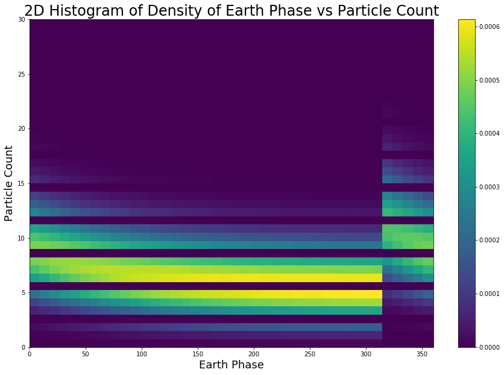

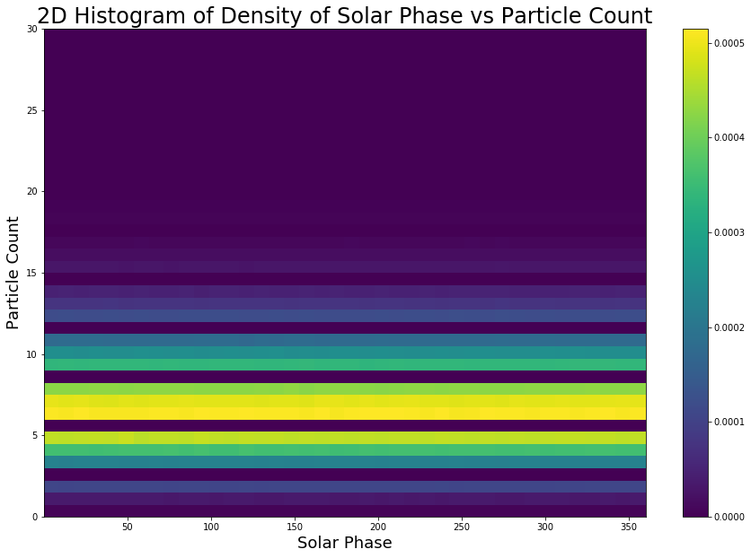

```python
# 2d hist plot of earth phase vs particle count
fig, ax = plt.subplots(1, 1)
fig.set_figheight(10)
fig.set_figwidth(15)
h = ax.hist2d(ephase, pcount,bins=(40,40), density=True);
plt.title("2D Histogram of Density of Earth Phase vs Particle Count", fontsize = 24)
plt.ylabel("Particle Count", fontsize = 18)
plt.xlabel("Earth Phase", fontsize = 18)
fcb = plt.colorbar(h[3], ax=ax);

# 2d hist plot of solar phase vs particle count
fig, ax = plt.subplots(1, 1)
fig.set_figheight(10)
fig.set_figwidth(15)
h = ax.hist2d(sphase, pcount,bins=(40,40), density=True);
plt.title("2D Histogram of Density of Solar Phase vs Particle Count", fontsize = 24)
plt.ylabel("Particle Count", fontsize = 18)
plt.xlabel("Solar Phase", fontsize = 18)
fcb = plt.colorbar(h[3], ax=ax);
```

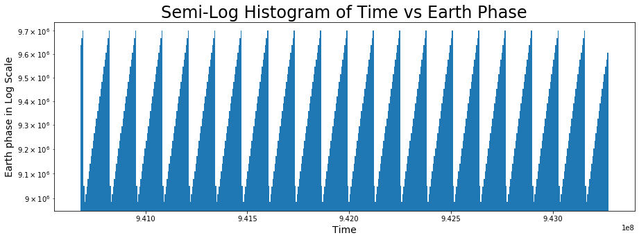

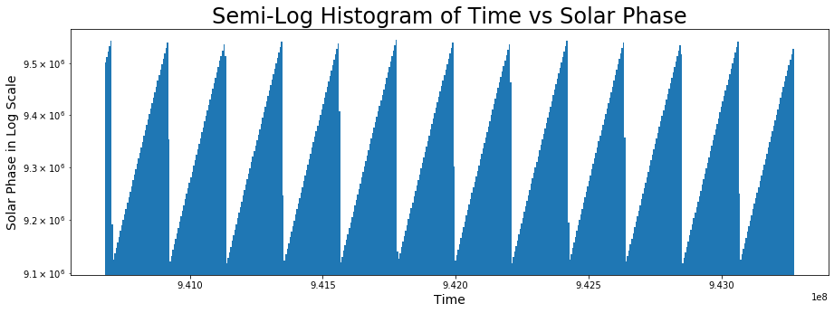

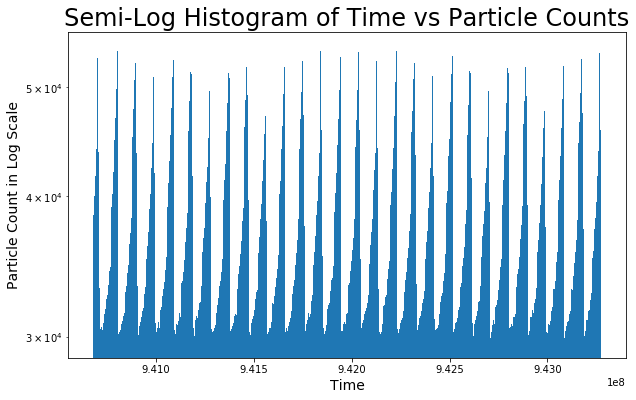

```python
# hist plot of time vs earth phase
plt.figure(figsize=(15,5))
plt.hist(time, weights=ephase, bins=500)
plt.xlabel("Time", fontsize=14)
plt.ylabel("Earth phase in Log Scale", fontsize=14)
plt.title("Semi-Log Histogram of Time vs Earth Phase", fontsize=24)
plt.yscale('log')
plt.show()

# hist plot of time vs solar phase
plt.figure(figsize=(15,5))
plt.hist(time, weights=sphase, bins=500)
plt.xlabel("Time", fontsize=14)
plt.ylabel("Solar Phase in Log Scale", fontsize=14)
plt.title("Semi-Log Histogram of Time vs Solar Phase", fontsize=24)
plt.yscale('log')
plt.show()

# hist plot of time vs particle count
plt.figure(figsize=(10,6))
plt.hist(time, weights=pcount, bins=5000)
plt.yscale('log')
plt.xlabel("Time", fontsize=14)
plt.ylabel("Particle Count in Log Scale", fontsize=14)
plt.title("Semi-Log Histogram of Time vs Particle Counts", fontsize=24)
plt.show()
```

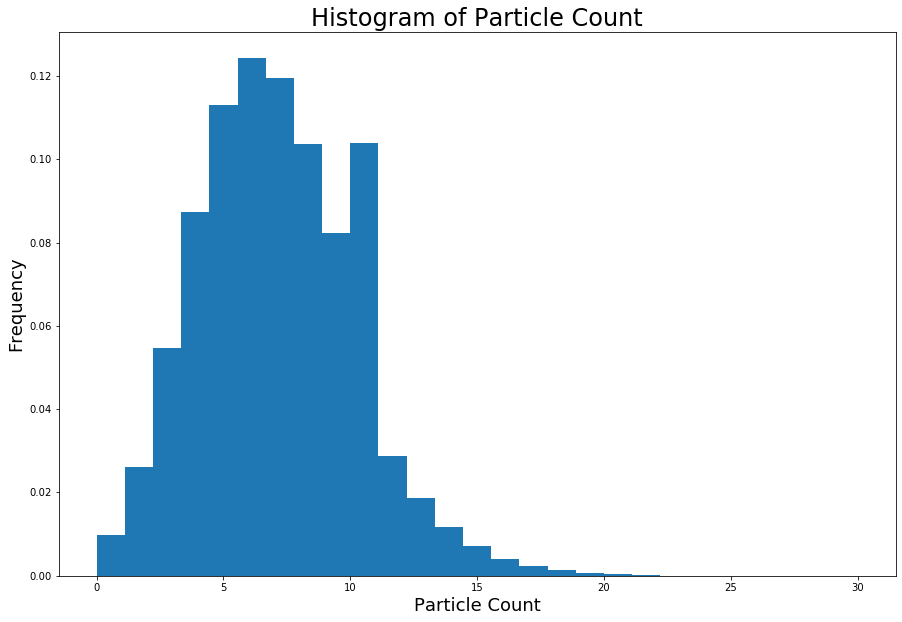

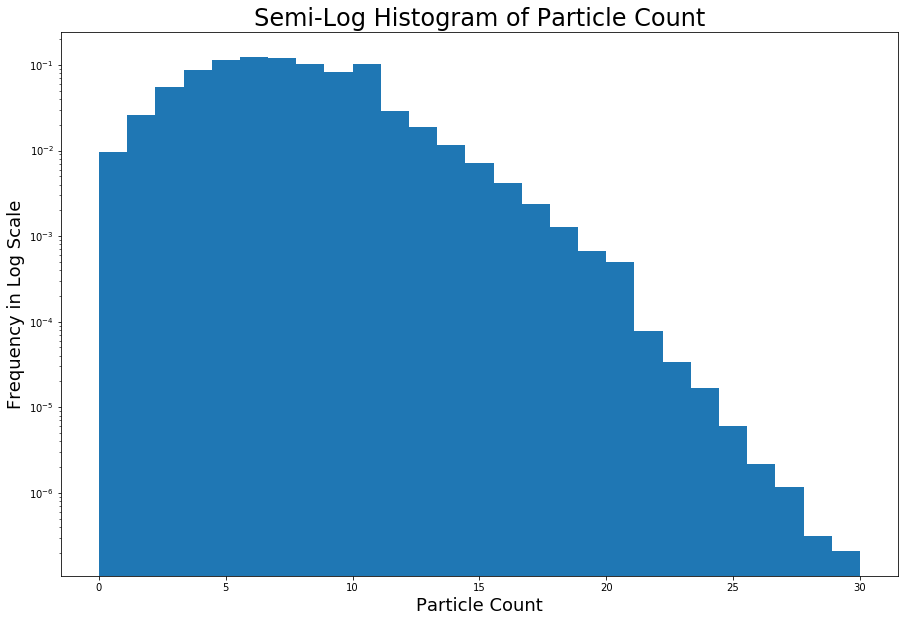

```python
# hist plot of particle count frequency
plt.figure(figsize=(15,10))
plt.hist(pcount, density=True, bins=27)
plt.xlabel("Particle Count", fontsize=18)
plt.ylabel("Frequency", fontsize=18)
plt.title("Histogram of Particle Count", fontsize=24)
plt.show()

plt.figure(figsize=(15,10))
plt.hist(pcount, density=True, bins=27)
plt.yscale('log')
plt.xlabel("Particle Count", fontsize=18)
plt.ylabel("Frequency in Log Scale", fontsize=18)
plt.title("Semi-Log Histogram of Particle Count", fontsize=24);
plt.show()
```

**Section 1.2**

The background is not consistent with the data set. We know this because the particle count is dependent on the earth phase. In the plot below, we notice a discontinuity at approximately 320 degrees. Again, we notice how the particle count is steadily decaying in the region from 0 to 320 degrees at which the particle count suddenly increases to decay again. This shows sigma contamination since the mean is constantly shifting since particle count is dependent on earth phase. So the background changes because of the earth phase.

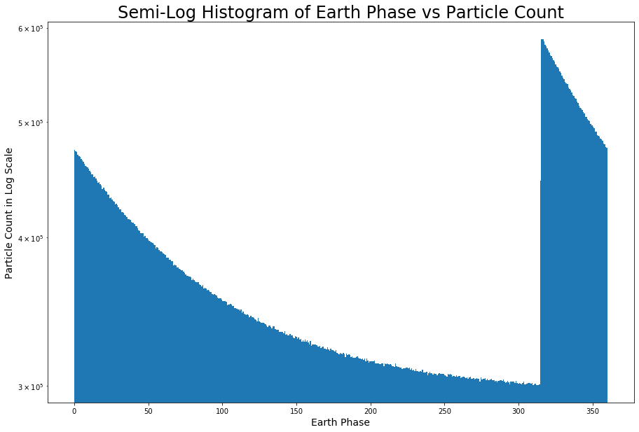

```python
# hist plot of time vs earth phase
plt.figure(figsize=(15,10))
d = plt.hist(ephase, weights=pcount, bins=500)
plt.xlabel("Earth Phase", fontsize=14)
plt.ylabel("Particle Count in Log Scale", fontsize=14)
plt.title("Semi-Log Histogram of Earth Phase vs Particle Count", fontsize=24)
plt.yscale('log')
plt.show()
```

**Section 1.3**

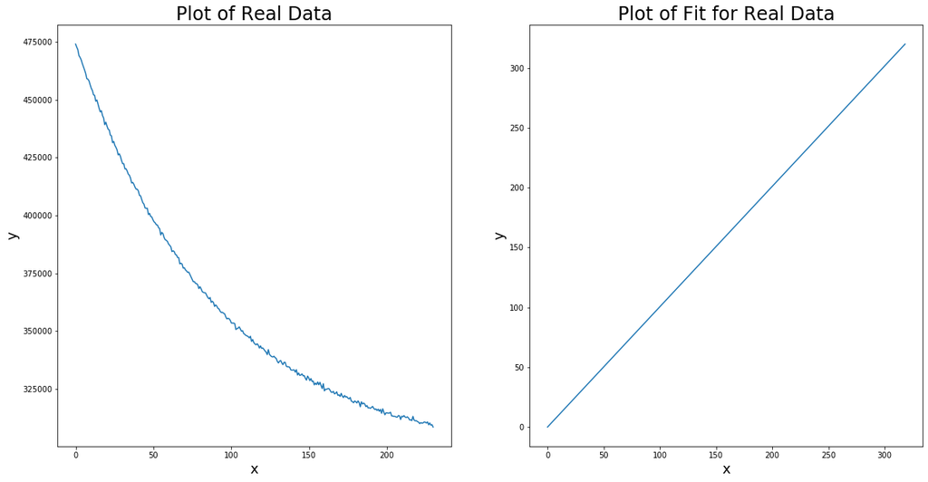

```python
xvals = []
for x in range(320):
    xvals.append(d[1][x])

yvals = []
for y in range(320):
    yvals.append(d[0][y])

# for some reason, expd is not plotting
A = yvals[0]
B = np.log((yvals[319]/yvals[0])/320)
C = 0

# i dont know how to plot the exponential function......
expd = []
for i in range(319):
    yval = A*np.exp(B*xvals[i])+C
    expd.append(yval)

fig, ax = plt.subplots(1,2)
fig.set_size_inches(20,10)
ax[0].plot(xvals, yvals)
ax[0].set_title("Plot of Real Data", fontsize=24)
ax[0].set_xlabel("x", fontsize=18)
ax[0].set_ylabel("y", fontsize=18)
ax[1].plot(np.linspace(0,320, len(expd), expd))
ax[1].set_title("Plot of Fit for Real Data", fontsize=24)
ax[1].set_xlabel("x", fontsize=18)
ax[1].set_ylabel("y", fontsize=18)
```

**Section 1.4**

Now, we want to find the signal associated with five-sigma detection. Specifically, we are interested in the five-sigma threshold for a 100 ms gamma-ray burst at different times. Below is my calculations for this.

```python
fivesigma = 1-stats.norm.cdf(5)
det1 = stats.poisson.ppf(1-fivesigma, 320)
print(det1)

fivesigma = 1-stats.norm.cdf(5)
det2 = stats.poisson.ppf(1-fivesigma, 321)
print(det2)
```

```
413.0
414.0
```

### **Problem 2**

Here, we will be looking at a stack of ten simulated telescope images. Our goal is to find the faintest stars and a transient (which is equivalent to a super novae). I will pursue the goal of finding the faintest stars while my lab partner will pursue the other goal of finding the transient which only appears in one image. We are told the images are square with 200 pixel on a side.

**Section 2.1**

Here, we want to download the ten simulated telescope images. We follow the same process as the previous part but we aren't given the keys of the data set. We can get these keys by using .keys(). Below, we print the keys and store the data sets.

```python
hf = h5py.File('images.h5', 'r')
print(hf.keys())
image1 = np.array(hf.get('image1'))
imagestack = np.array(hf.get('imagestack'))
hf.close()
```

```
<KeysViewHDF5 ['image1', 'imagestack']>
```

**Section 2.2**

From each of the ten images, we see outliers appear after an intensity of 30. These intensities are most likely related to the transient which I am not exploring. Otherwise, a majority of the data lies in the region before an intensity of 30 which is where I would find the dimmest stars. There is signal contamination in the pdf() from all of the zero intensity spots in the image which are most likely empty space. This is because I am interested in finding dimmest stars but the zero intensity spots would affect the signal and contribute nothing of value to me. Now, we notice how the images doesn't change too drastically which means the background isn't time dependent. Also, each pdf() shows the background is consistent spatially. This is because a majority of the image is empty space which is associated with zero intensity. However, we do see some bright spots too.

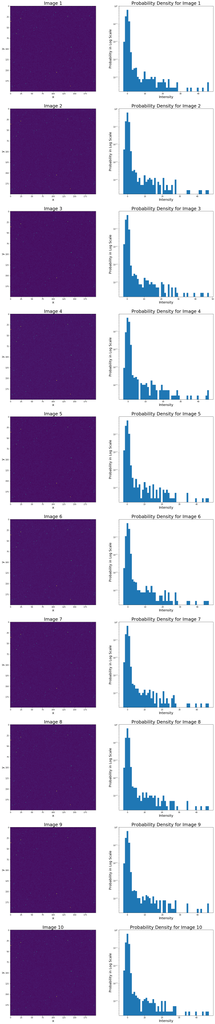

```python
fig, ax = plt.subplots(10, 2)
fig.set_size_inches(20,100)

for i in range(10):
    # show image
    ax[i,0].imshow(imagestack[:,:,i])
    ax[i,0].set_title(f"Image {i+1}", fontsize=24)
    ax[i,0].set_xlabel("x", fontsize=18)
    ax[i,0].set_ylabel("y", fontsize=18)

    # store and plot pdf data for associated image
    intensity = []
    for j in range(200):
        for k in range(200):
            intensity.append(imagestack[j,k,i])

    ax[i,1].hist(intensity, density=True, bins=50)
    ax[i,1].set_yscale('log')
    ax[i,1].set_title(f"Probability Density for Image {i+1}", fontsize=24)
    ax[i,1].set_xlabel("Intensity", fontsize=18)
    ax[i,1].set_ylabel("Probability in Log Scale", fontsize=18)
```

**Section 2.3**

```
We get a sigma of 0.991 and a mean of 0.033
```

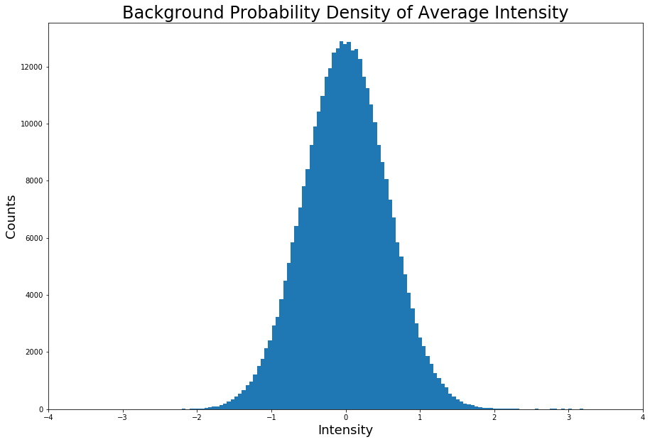

```python
intensity_avg = []
for i in range(200):
    for j in range(200):
        for k in range(9):
            avg = np.mean(images[i,j,k])
            intensity_avg.append(avg)

plt.figure(figsize=(15,10))
plt.hist(intensity_avg, bins=1000)
plt.title("Background Probability Density of Average Intensity", fontsize=24)
plt.xlabel("Intensity", fontsize=18)
plt.ylabel("Counts", fontsize=18)
plt.xlim(-4, 4);

# calculate associated sigma and mean
sigma = np.std(intensity_avg)
mean = np.mean(intensity_avg)
print('We get a sigma of {0:1.3f}'.format(sigma), 'and a mean of {0:1.3f}'.format(mean))
```

```python
sig = scipy.stats.norm.cdf(intensity_avg[0], loc=mean, scale=sigma)
print("The dimmest star has intensity of {0:1.3f}".format(intensity_avg[0]), "which is associated with a signal of {0:1.3f}".format(sig))
```

```
The dimmest star has intensity of -2.709 which is associated with a signal of 0.003
```

**Section 2.4**